# lab_1

```python
import pandas as pd
import numpy as np
from sklearn.decomposition import PCA, KernelPCA
from sklearn import preprocessing
from memory_profiler import memory_usage
import matplotlib.pyplot as plt
from sklearn.model_selection import train_test_split
from sklearn.preprocessing import StandardScaler
from sklearn.datasets import fetch_lfw_people, make_blobs
```

## 1. Analiza zbioru dancych NYT

```python
# Dataframe reading
df = pd.read_csv('./nyt-frame.csv', header = 0)
data = df.iloc[:,9:]
array = data.values

header = list(df.columns.values[9:])
sample_word = np.random.choice(header, 20, replace=False)
print(sample_word)
```

```
['broadcast' 'whose' 'involvement' 'obliterate' 'harder' 'g' 'arts'
 'flavored' 'neither' 'notion' 'tourists' 'dinner' 'sales' 'cellist'
 'emerging' 'colorful' 'previous' 'rocky' 'surprise' 'whenever']
```

```python
# PCA transformation
pca = PCA()
X_pca = pca.fit_transform(array)
```

```python
# Component 1 - biggest and smallest elements
pc1 = pca.components_[0]
idx_max = np.argsort(pc1)[-15:][::-1]
idx_min = np.argsort(pc1)[:15]

print(f'Top 15 +PC1 words:', [header[i] for i in idx_max])
print(f'Top 15 -PC1 words:', [header[i] for i in idx_min])

pc2 = pca.components_[1]
idx_max2 = np.argsort(pc2)[-15:][::-1]
idx_min2 = np.argsort(pc2)[:15]

# Component 2 - biggest and smallest elements
print(f'Top 15 +PC2 words:', [header[i] for i in idx_max2])
print(f'Top 15 -PC2 words:', [header[i] for i in idx_min2])
```

```
Top 15 +PC1 words: ['she', 'her', 'ms', 'i', 'said', 'mother', 'cooper', 'my', 'painting', 'process', 'paintings', 'im', 'mrs', 'he', 'me']
Top 15 -PC1 words: ['music', 'trio', 'theater', 'orchestra', 'composers', 'opera', 'theaters', 'm', 'program', 'players', 'festival', 'east', 'y', 'jersey', 'symphony']
Top 15 +PC2 words: ['her', 'she', 'theater', 'opera', 'ms', 'i', 'hour', 'sang', 'production', 'festival', 'music', 'musical', 'songs', 'orchestra', 'vocal']
Top 15 -PC2 words: ['art', 'museum', 'images', 'artists', 'donations', 'museums', 'painting', 'tax', 'paintings', 'sculpture', 'gallery', 'sculptures', 'painted', 'white', 'service']
```

Analizujac powyższe rezultaty możemy zauważyć iż wśród elementów o największej wartości dla pierwszego komponentu dominują słowa takie jak `'she', 'her', 'ms', 'i', 'said'`, czyli związane z narracją. Natomiast słowa związane z muzyką takie jak `'music', 'trio', 'theater', 'orchestra'`, znalazły się pośród elementów o najmniejszej wartości. Jesli chodzi o drugi komponent , to elementy o najwięszej wartośći, wskazują na dziedziny takie jak teatr, opera czy festiwal, które można sklasyfikować jako sztuki performatywne. Elementy o najmnieszej wartości, to m.in `'art', 'museum', 'images'`, czyli słowa odnoszące się do sztuk wizualnych. Podsumowując pierwszy komponent wychwytuje różnicę między stylem narracyjnym a tematyką muzyczną, natomiast drugi komponent rozróżnia różne dziedziny sztuki

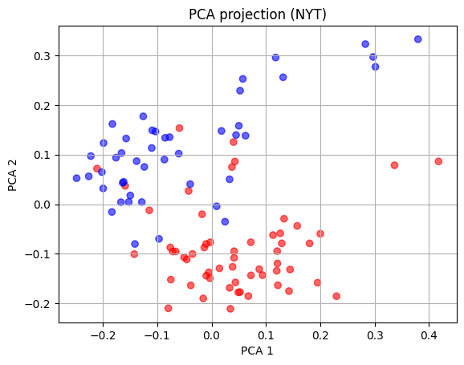

```python
# Visualisations 2D

def plot_2d_projection(x1, x2,  method_name="PCA"):

    labels = df['class.labels'].values
    colors = ['red' if l =='art' else 'blue' for l in labels]

    plt.figure()
    plt.scatter(x1, x2, c=colors, alpha=0.6)
    plt.title(f"{method_name} projection (NYT)")
    plt.xlabel(f"{method_name} 1")
    plt.ylabel(f"{method_name} 2")

    plt.grid(True)
    plt.show()

plot_2d_projection(X_pca[:, 0], X_pca[:, 1])
```

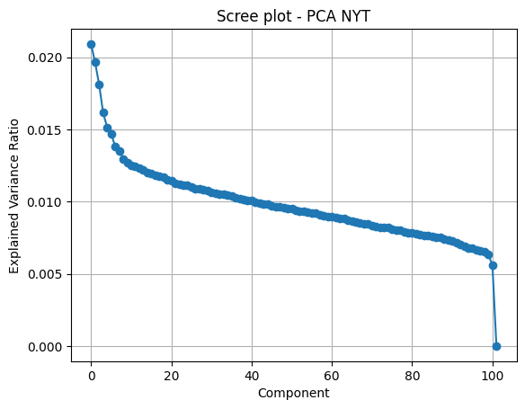

```
Cumulative variance (top 10): 0.1577
```

```python
# Scree plot

def show_scree_plot(variance_ratio, title):
    plt.figure()
    plt.plot(variance_ratio, 'o-')
    plt.title(title)
    plt.xlabel("Component")
    plt.ylabel("Explained Variance Ratio")
    plt.grid(True)
    plt.show()
variance_ratio = pca.explained_variance_ratio_
show_scree_plot(variance_ratio, "Scree plot - PCA NYT")
print(f'Cumulative variance (top 10): {sum(variance_ratio[0:10]):.4f}')
```

Skomentuj w jaki sposób inne niż domyśle wartości argumentów konstruktora `sklearn.decomposition.PCA` mogą być przydatne w rozwiązaniu tego zadania:

- n components: None, int, float, ’mle’
- copy
- whiten
- svd solver: ’auto’, ’full’, ’arpack’, ’randomized’

W konstruktorze `sklearn.decomposition.PCA` dostępne są różne parametry, które wpływają na działanie analizy i jej interpretację.

#### `n_components`

Parametr określa liczbę komponentów głównych:

- `int` – wybór konkretnej liczby komponentów (np. 2)
- `float` – procent wariancji do zachowania (np. 0.9)
- `'mle'` – automatyczny dobór liczby komponentów

Pozwala ograniczyć liczbę komponentów do najważniejszych, co ułatwia analizę danych tekstowych.

#### `copy`

- `True` – tworzy kopię danych
- `False` – nadpisuje dane wejściowe

Może zmniejszyć zużycie pamięci przy pracy z dużymi zbiorami tekstów.

#### `whiten`

- `True` – skaluje komponenty do wariancji równej 1

Może poprawić działanie dalszych algorytmów (np. klasyfikacji), ale utrudnia interpretację komponentów (zmienia znaczenie wag słów).

#### `svd_solver`

Określa metodę obliczania PCA:

- `'full'` – dokładna, wolniejsza
- `'arpack'` – dla wybranej liczby komponentów
- `'randomized'` – szybsza dla dużych danych
- `'auto'` – automatyczny wybór

Dla dużych macierzy tekstowych warto użyć `'randomized'` dla szybszych obliczeń, natomiast `'full'` daje dokładniejsze wyniki dla mniejszych danych.

10⋆ Porównaj metody t-SNE oraz UMAP z PCA (wizualizacja 2D). Czy nieliniowe metody (np. UMAP) lepiej separują klasy w danych NYT niż PCA?

#### T-distributed Stochastic Neighbor Embedding.

t-SNE [1] is a tool to visualize high-dimensional data. It converts similarities between data points to joint probabilities and tries to minimize the Kullback-Leibler divergence between the joint probabilities of the low-dimensional embedding and the high-dimensional data. t-SNE has a cost function that is not convex, i.e. with different initializations we can get different results.

```python
from sklearn.manifold import TSNE

tsne = TSNE(method='exact',random_state=42,  n_jobs=-1)
X_tnse = tsne.fit_transform(array)
```

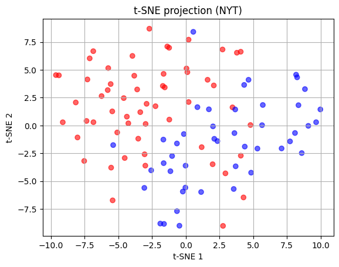

```python
plot_2d_projection(X_tnse[:, 0], X_tnse[:, 1], method_name='t-SNE')
```

```python
import umap

reducer = umap.UMAP(random_state=42, n_jobs=1)

X_umap = reducer.fit_transform(array)
```

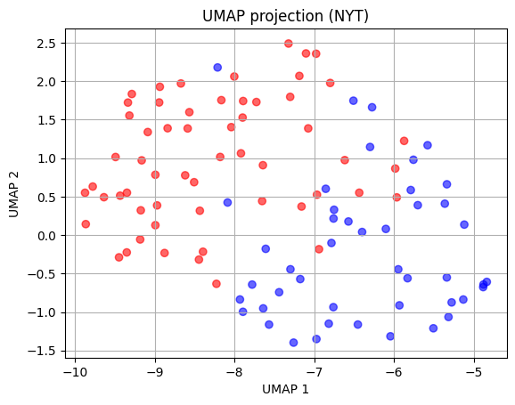

```python
plot_2d_projection(X_umap[:, 0], X_umap[:, 1], method_name='UMAP')
```

[figure not shown]

## 2. Analiza zbioru danych 04Cars

```python
# Data reading

df = pd.read_csv('./04cars-data.csv', header=0)
data = df.iloc[:, 9:]
df.head()
```

|  | Vehicle Name | Small/Sporty/ Compact/Large Sedan | Sports Car | SUV | Wagon | Minivan | Pickup | AWD | RWD | Retail Price | Dealer Cost | Engine Size (l) | Cyl | HP | City MPG | Hwy MPG | Weight | Wheel Base | Len | Width |
| --- | --- | --- | --- | --- | --- | --- | --- | --- | --- | --- | --- | --- | --- | --- | --- | --- | --- | --- | --- | --- |
| 0 | Acura 3.5 RL 4dr | 1 | 0 | 0 | 0 | 0 | 0 | 0 | 0 | 43755 | 39014 | 3.5 | 6 | 225 | 18 | 24 | 3880 | 115 | 197 | 72 |
| 1 | Acura 3.5 RL w/Navigation 4dr | 1 | 0 | 0 | 0 | 0 | 0 | 0 | 0 | 46100 | 41100 | 3.5 | 6 | 225 | 18 | 24 | 3893 | 115 | 197 | 72 |
| 2 | Acura MDX | 0 | 0 | 1 | 0 | 0 | 0 | 1 | 0 | 36945 | 33337 | 3.5 | 6 | 265 | 17 | 23 | 4451 | 106 | 189 | 77 |
| 3 | Acura NSX coupe 2dr manual S | 0 | 1 | 0 | 0 | 0 | 0 | 0 | 1 | 89765 | 79978 | 3.2 | 6 | 290 | 17 | 24 | 3153 | 100 | 174 | 71 |
| 4 | Acura RSX Type S 2dr | 1 | 0 | 0 | 0 | 0 | 0 | 0 | 0 | 23820 | 21761 | 2.0 | 4 | 200 | 24 | 31 | 2778 | 101 | 172 | 68 |

```python
data_scaled =  preprocessing.scale(data)
```

```python
#MEAN
data_scaled.mean(axis=0)
```

```
array([-4.13106242e-17,  4.13106242e-17, -6.05889155e-16, -1.00981526e-16,
       -1.79012705e-16, -4.59006935e-18, -7.57361443e-17, -2.06553121e-16,
        7.89491929e-16, -6.70150125e-16,  1.78094691e-15])
```

```python
#STD
data_scaled.std(axis=0)
```

```
array([1., 1., 1., 1., 1., 1., 1., 1., 1., 1., 1.])
```

```python
pca = PCA()
X_pca = pca.fit_transform(data_scaled)
attributes = df.columns.values[9:]
explained_var_ratio = pca.explained_variance_ratio_

explained_var = pca.explained_variance_

print("Explained variance ratio):\n", explained_var_ratio)
print("Explained variance):\n", explained_var)
```

```
Explained variance ratio):
 [6.45876221e-01 1.71265888e-01 7.72480259e-02 3.24559536e-02
 2.50395994e-02 1.79948832e-02 1.27744735e-02 7.87625563e-03
 6.03527097e-03 3.36157838e-03 7.18504308e-05]
Explained variance):
 [7.12304423e+00 1.88880540e+00 8.51929654e-01 3.57940400e-01
 2.76149157e-01 1.98456523e-01 1.40883248e-01 8.68632648e-02
 6.65599703e-02 3.70731584e-02 7.92402290e-04]
```

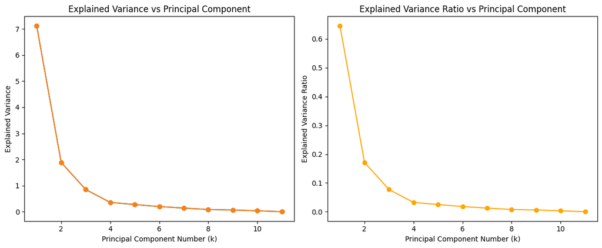

```python
k = np.arange(1, len(explained_var_ratio) + 1)

plt.figure(figsize=(12,5))

plt.subplot(1, 2, 1)
plt.plot(k, explained_var, marker='o')
plt.plot(k, explained_var, marker='o')
plt.title("Explained Variance vs Principal Component")
plt.xlabel("Principal Component Number (k)")
plt.ylabel("Explained Variance")

plt.subplot(1, 2, 2)
plt.plot(k, explained_var_ratio, marker='o', color='orange')
plt.title("Explained Variance Ratio vs Principal Component")
plt.xlabel("Principal Component Number (k)")
plt.ylabel("Explained Variance Ratio")

plt.tight_layout()
plt.show()
```

Przy redukcji wymiarowości do 2 składowych zachowane zostaje około 81.7% całkowitej wariancji, natomiast dla 3 składowych około 89.4% wariancji. Oznacza to, że już pierwsze trzy kierunki główne opisują większość informacji zawartej w danych.

```python
pc1 = pca.components_[0]
pc2 = pca.components_[1]
print(f'Attribute, PC1, PC2')
for i in range(0, pc1.shape[0]):
    print(attributes[i] + ':' + repr(pc1[i]) + repr(pc2[i]))
```

```
Attribute, PC1, PC2
Retail Price:np.float64(0.2637504434440344)np.float64(0.46850869750253865)
Dealer Cost:np.float64(0.2623186387530948)np.float64(0.47014658513822577)
Engine Size (l):np.float64(0.34708049202520075)np.float64(-0.015347186463713414)
Cyl:np.float64(0.3341887576286369)np.float64(0.07803201087501863)
HP:np.float64(0.318602258484029)np.float64(0.29221347613918197)
City MPG:np.float64(-0.31048172673231267)np.float64(-0.003365935761659389)
Hwy MPG:np.float64(-0.30658863858044416)np.float64(-0.010964460145348895)
Weight:np.float64(0.33632936694048776)np.float64(-0.16746357154787028)
Wheel Base:np.float64(0.2662100335710542)np.float64(-0.41817710695920407)
Len:np.float64(0.2567901876706821)np.float64(-0.40841138066875443)
Width:np.float64(0.29605459141706103)np.float64(-0.3128913501625069)
```

Elementy o wartościach bliskich zeru oznaczają, że dana cecha ma niewielki wpływ na dany komponent główny.

Pierwszy komponent główny (PC1) jest silnie związany z cechami opisującymi wielkość i moc samochodu, takimi jak pojemność silnika, liczba cylindrów, masa oraz moc. Jednocześnie ma wartości ujemne dla zużycia paliwa (City MPG, Hwy MPG), co wskazuje, że większe i mocniejsze pojazdy są mniej ekonomiczne.

Drugi komponent główny (PC2) jest przede wszystkim powiązany z ceną pojazdu (Retail Price, Dealer Cost) oraz częściowo z jego mocą. Ujemne wartości dla wymiarów pojazdu (długość, szerokość, rozstaw osi) sugerują, że komponent ten rozróżnia samochody pod względem wartości rynkowej w stosunku do ich rozmiaru.

```python
pc1, pc2 = pca.components_[:2]
df_with_attrs = pd.DataFrame({
'Attribute': attributes,
'PC1': pc1,
'PC2': pc2})

display(df_with_attrs)
```

|  | Attribute | PC1 | PC2 |
| --- | --- | --- | --- |
| 0 | Retail Price | 0.263750 | 0.468509 |
| 1 | Dealer Cost | 0.262319 | 0.470147 |
| 2 | Engine Size (l) | 0.347080 | -0.015347 |
| 3 | Cyl | 0.334189 | 0.078032 |
| 4 | HP | 0.318602 | 0.292213 |
| 5 | City MPG | -0.310482 | -0.003366 |
| 6 | Hwy MPG | -0.306589 | -0.010964 |
| 7 | Weight | 0.336329 | -0.167464 |
| 8 | Wheel Base | 0.266210 | -0.418177 |
| 9 | Len | 0.256790 | -0.408411 |
| 10 | Width | 0.296055 | -0.312891 |

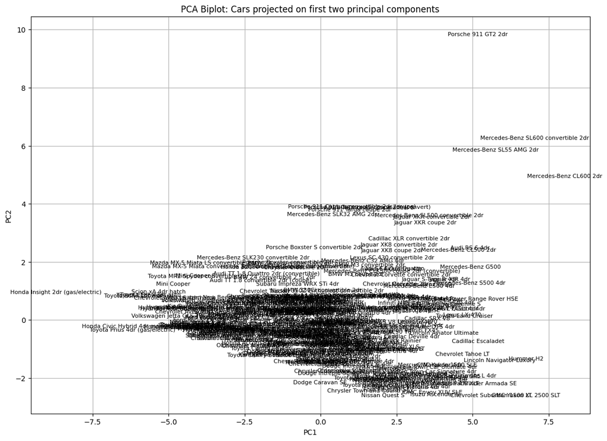

```python
xs = X_pca[:, 0]
ys = X_pca[:, 1]

coef = np.transpose(pca.components_[:2, :])
n_features = coef.shape[0]

plt.figure(figsize=(14,10))

plt.scatter(xs, ys, color='white')


for i in range(len(df)):
    plt.text(xs[i], ys[i], df['Vehicle Name'][i], fontsize=8, ha='center', va='center')

plt.xlabel("PC1")
plt.ylabel("PC2")
plt.title("PCA Biplot: Cars projected on first two principal components")
plt.grid(True)
plt.show()
```

Na wykresie przedstawiono dane zrzutowane na dwie pierwsze składowe główne (PC1 i PC2). Oś pozioma (PC1) odpowiada głównie za rozmiar i moc pojazdu, natomiast oś pionowa (PC2) wiąże się przede wszystkim z ceną samochodu.

W prawym górnym obszarze (wysokie wartości PC1 i PC2) znajdują się samochody luksusowe i sportowe, takie jak Porsche 911 GT, Mercedes CL600 czy Mercedes SL55 AMG. Są to pojazdy o dużej mocy, dużych rozmiarach oraz wysokiej cenie.

W prawym dolnym obszarze (wysokie PC1, niskie PC2) znajdują się duże samochody o znacznej masie i dużych silnikach, ale relatywnie mniej luksusowe, takie jak Cadillac Escalade czy Lincoln Navigator.

Samochody znajdujące się w centralnej części wykresu reprezentują typowe pojazdy klasy średniej, o przeciętnych wartościach cech takich jak moc, rozmiar i cena.

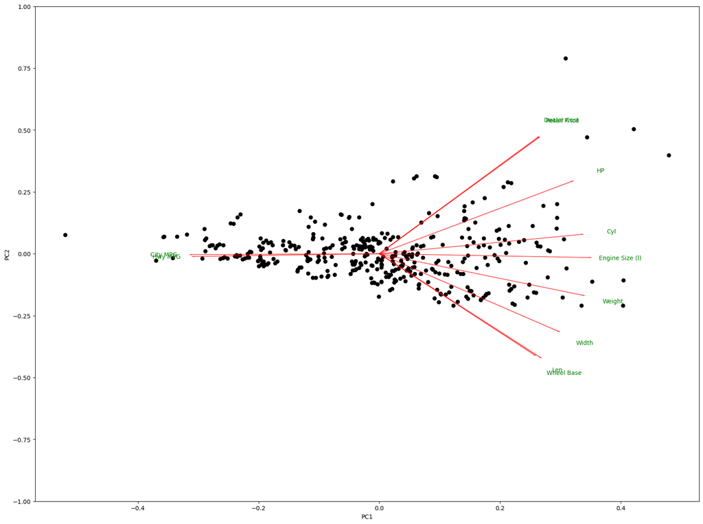

```python
def myplot(score, coef, labels=None):
    plt.figure(figsize=(20, 15))
    plt.xlabel("PC{}".format(1))
    plt.ylabel("PC{}".format(2))
    xs = score[:, 0]
    ys = score[:, 1]
    n = coef.shape[0]
    scalex = 1.0 / (xs.max() - xs.min())
    scaley = 1.0 / (ys.max() - ys.min())

    plt.scatter(xs * scalex, ys* scaley, color='black')

    for i in range(n):
        plt.arrow(0, 0, coef[i, 0], coef[i, 1], color= 'r', alpha =0.5)
        if labels is None:
            plt.text(coef[i, 0] * 1.15, coef[i, 1] * 1.15, "Var" + str(i+1), color='g', ha='center', va='center')

        else:
            plt.text(coef[i, 0] * 1.15, coef[i, 1] * 1.15, labels[i], color='g', ha='center', va='center')

myplot(X_pca[:, 0:2], np.transpose(pca.components_[:2, :]), attributes)
axes = plt.gca()
axes.set_ylim(-1.0, 1.0)
plt.show()
```

Biplot przedstawia jednocześnie samochody w przestrzeni dwóch pierwszych składowych głównych oraz wektory cech. Strzałki reprezentują kierunek i siłę wpływu poszczególnych cech na wynik PCA.

Wektory cen (Retail Price, Dealer Cost) skierowane są w prawy górny obszar wykresu, co wskazuje na ich silny związek z obiema składowymi, szczególnie z komponentem odpowiadającym za wartość pojazdu.

Wektory mocy (HP) oraz liczby cylindrów (Cyl) są również skierowane w prawo, co oznacza ich silny związek z pierwszym komponentem opisującym wielkość i wydajność pojazdu.

Pojemność silnika (Engine Size) jest niemal równoległa do osi PC1, co wskazuje, że wpływa głównie na pierwszy komponent.

Cechy związane z rozmiarem pojazdu, takie jak masa, długość, szerokość i rozstaw osi, mają dodatni wpływ na pierwszy komponent, ale ujemny na drugi, co sugeruje ich odwrotną relację z ceną w analizowanym zbiorze danych.

## 3.Budowa eigenfaces w oparciu o zbiór danych LFW

```python
lfw = fetch_lfw_people(min_faces_per_person=50, resize=0.4)

print(lfw.images.shape)
print(lfw.target.shape)
print(lfw.target_names)
```

```
(1560, 50, 37)
(1560,)
['Ariel Sharon' 'Colin Powell' 'Donald Rumsfeld' 'George W Bush'
 'Gerhard Schroeder' 'Hugo Chavez' 'Jacques Chirac' 'Jean Chretien'
 'John Ashcroft' 'Junichiro Koizumi' 'Serena Williams' 'Tony Blair']
```

```python
print(lfw.keys())
```

```
dict_keys(['data', 'images', 'target', 'target_names', 'DESCR'])
```

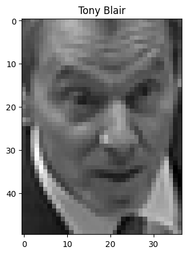

```python
plt.imshow(lfw.images[0], cmap='gray')
plt.title(lfw.target_names[lfw.target[0]])
plt.show()
```

```python
X = lfw.data
y = lfw.target

x_train, x_test, y_train, y_test = train_test_split(
    X, y,
    train_size=0.7,
    random_state=42
)
```

```python
lfw_pca = PCA(n_components=100)
x_train_pca = lfw_pca.fit_transform(x_train)
x_test_pca = lfw_pca.transform(x_test)
```

```python
print(lfw_pca.explained_variance_ratio_)
```

```
[0.24492349 0.13090406 0.06840751 0.05537867 0.04403336 0.02658966
 0.02082502 0.01921097 0.01770739 0.01645367 0.01403754 0.01333778
 0.0111809  0.01013466 0.0098353  0.00907651 0.00842629 0.00797663
 0.00743181 0.00709222 0.00654406 0.00633573 0.00550954 0.00517476
 0.00504507 0.00490827 0.00476166 0.00446724 0.00436301 0.00399054
 0.00378309 0.00352968 0.00344663 0.00337705 0.00328428 0.00313219
 0.00300746 0.00297321 0.00285719 0.00270192 0.0026258  0.00257765
 0.00255258 0.00249172 0.00242645 0.00239569 0.00226237 0.00222808
 0.0022112  0.00217664 0.00213958 0.00209266 0.00199048 0.00197775
 0.00193725 0.00190006 0.00184456 0.00180215 0.00175195 0.00167908
 0.00166374 0.00162592 0.00160316 0.00155879 0.00153766 0.00148766
 0.00146973 0.00144668 0.00142494 0.00139653 0.00138315 0.00136146
 0.0013304  0.00128667 0.00126261 0.00123429 0.00123102 0.00117843
 0.00115868 0.00113526 0.00112758 0.00111323 0.00109926 0.00106833
 0.00106082 0.00104738 0.00103073 0.00101311 0.00100312 0.00098998
 0.00097611 0.00096951 0.00095339 0.00093401 0.0009168  0.00090051
 0.00088498 0.00087887 0.0008597  0.00084677]
```

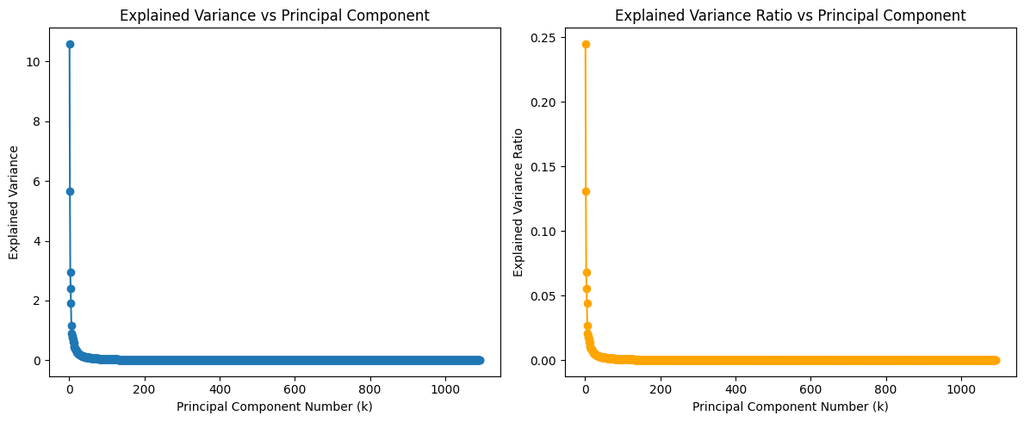

```python
lfw_pca = PCA()
x_train_pca_full  = lfw_pca.fit_transform(x_train)
x_test_pca_full = lfw_pca.transform(x_test)
k = np.arange(1, len(lfw_pca.explained_variance_ratio_) + 1)

plt.figure(figsize=(12,5))

plt.subplot(1, 2, 1)
plt.plot(k, lfw_pca.explained_variance_, marker='o')
plt.title("Explained Variance vs Principal Component")
plt.xlabel("Principal Component Number (k)")
plt.ylabel("Explained Variance")

plt.subplot(1, 2, 2)
plt.plot(k, lfw_pca.explained_variance_ratio_, marker='o', color='orange')
plt.title("Explained Variance Ratio vs Principal Component")
plt.xlabel("Principal Component Number (k)")
plt.ylabel("Explained Variance Ratio")

plt.tight_layout()
plt.show()
```

```python
from sklearn import svm
from sklearn.ensemble import RandomForestClassifier

clf_svm = svm.SVC(
    C=10,
    kernel='rbf',
    gamma='scale',
    class_weight='balanced'
)
clf_svm.fit(x_train_pca, y_train)
```

```
SVC(C=10, class_weight='balanced')
```

```python
clf_rf = RandomForestClassifier(
    n_estimators=200,
    max_features='sqrt',
    class_weight='balanced',
    random_state=42
)
clf_rf.fit(x_train_pca, y_train)
```

```
RandomForestClassifier(class_weight='balanced', n_estimators=200,
                       random_state=42)
```

```python
from sklearn.metrics import classification_report, mean_squared_error


def evaluate_model(model, x_test, y_test):
    y_pred = model.predict(x_test)
    print(classification_report(y_test, y_pred, target_names=lfw.target_names, zero_division=0))
```

```python
print('------------------SVM Classifier metrics------------------')
evaluate_model(clf_svm, x_test_pca, y_test)
```

```
------------------SVM Classifier metrics------------------
                   precision    recall  f1-score   support

     Ariel Sharon       0.78      0.67      0.72        21
     Colin Powell       0.83      0.91      0.87        77
  Donald Rumsfeld       0.55      0.72      0.62        32
    George W Bush       0.81      0.88      0.84       162
Gerhard Schroeder       0.61      0.63      0.62        30
      Hugo Chavez       0.92      0.57      0.71        21
   Jacques Chirac       0.80      0.24      0.36        17
    Jean Chretien       0.88      0.82      0.85        17
    John Ashcroft       0.94      0.79      0.86        19
Junichiro Koizumi       0.92      0.85      0.88        13
  Serena Williams       1.00      0.85      0.92        13
       Tony Blair       0.73      0.72      0.73        46

         accuracy                           0.79       468
        macro avg       0.81      0.72      0.75       468
     weighted avg       0.80      0.79      0.78       468
```

```python
print('------------------RF Classifier metrics------------------')
evaluate_model(clf_rf, x_test_pca, y_test)
```

```
------------------RF Classifier metrics------------------
                   precision    recall  f1-score   support

     Ariel Sharon       1.00      0.05      0.09        21
     Colin Powell       0.94      0.42      0.58        77
  Donald Rumsfeld       1.00      0.16      0.27        32
    George W Bush       0.39      1.00      0.57       162
Gerhard Schroeder       0.00      0.00      0.00        30
      Hugo Chavez       0.00      0.00      0.00        21
   Jacques Chirac       0.00      0.00      0.00        17
    Jean Chretien       1.00      0.06      0.11        17
    John Ashcroft       0.00      0.00      0.00        19
Junichiro Koizumi       1.00      0.38      0.56        13
  Serena Williams       1.00      0.69      0.82        13
       Tony Blair       1.00      0.04      0.08        46

         accuracy                           0.46       468
        macro avg       0.61      0.23      0.26       468
     weighted avg       0.59      0.46      0.36       468
```

```python
lfw_pca_50 = PCA(n_components=50)
x_train_pca_50 = lfw_pca_50.fit_transform(x_train)
x_test_pca_50 = lfw_pca_50.transform(x_test)
```

```python
clf_svm_50 = svm.SVC(
    C=10,
    kernel='rbf',
    gamma='scale',
    class_weight='balanced'
)
clf_svm_50.fit(x_train_pca_50, y_train)
```

```
SVC(C=10, class_weight='balanced')
```

```python
clf_rf_50  = RandomForestClassifier(
    n_estimators=200,
    max_features='sqrt',
    class_weight='balanced',
    random_state=42
)
clf_rf_50.fit(x_train_pca_50, y_train)
```

```
RandomForestClassifier(class_weight='balanced', n_estimators=200,
                       random_state=42)
```

```python
print('------------------SVM Classifier metrics------------------')
evaluate_model(clf_svm_50, x_test_pca_50, y_test)
```

```
------------------SVM Classifier metrics------------------
                   precision    recall  f1-score   support

     Ariel Sharon       0.65      0.62      0.63        21
     Colin Powell       0.76      0.87      0.81        77
  Donald Rumsfeld       0.50      0.66      0.57        32
    George W Bush       0.82      0.83      0.83       162
Gerhard Schroeder       0.39      0.43      0.41        30
      Hugo Chavez       0.81      0.62      0.70        21
   Jacques Chirac       0.75      0.18      0.29        17
    Jean Chretien       0.81      0.76      0.79        17
    John Ashcroft       0.87      0.68      0.76        19
Junichiro Koizumi       0.92      0.85      0.88        13
  Serena Williams       0.92      0.85      0.88        13
       Tony Blair       0.70      0.70      0.70        46

         accuracy                           0.74       468
        macro avg       0.74      0.67      0.69       468
     weighted avg       0.75      0.74      0.73       468
```

```python
print('------------------RF Classifier metrics------------------')
evaluate_model(clf_rf_50, x_test_pca_50, y_test)
```

```
------------------RF Classifier metrics------------------
                   precision    recall  f1-score   support

     Ariel Sharon       1.00      0.10      0.17        21
     Colin Powell       0.81      0.60      0.69        77
  Donald Rumsfeld       0.67      0.19      0.29        32
    George W Bush       0.44      1.00      0.61       162
Gerhard Schroeder       1.00      0.07      0.12        30
      Hugo Chavez       1.00      0.10      0.17        21
   Jacques Chirac       0.00      0.00      0.00        17
    Jean Chretien       1.00      0.06      0.11        17
    John Ashcroft       0.00      0.00      0.00        19
Junichiro Koizumi       1.00      0.38      0.56        13
  Serena Williams       1.00      0.69      0.82        13
       Tony Blair       0.89      0.17      0.29        46

         accuracy                           0.52       468
        macro avg       0.73      0.28      0.32       468
     weighted avg       0.66      0.52      0.44       468
```

```python
lfw_pca_120 = PCA(n_components=120)
x_train_pca_120 = lfw_pca_120.fit_transform(x_train)
x_test_pca_120 = lfw_pca_120.transform(x_test)
```

```python
clf_svm_120 = svm.SVC(C=10,kernel='rbf', gamma='scale', decision_function_shape='ovo')
clf_svm_120.fit(x_train_pca_120, y_train)
```

```
SVC(C=10, decision_function_shape='ovo')
```

```python
clf_rf_120  = RandomForestClassifier(
    n_estimators=200,
    max_features='sqrt',
    class_weight='balanced',
    random_state=42
)
clf_rf_120.fit(x_train_pca_120, y_train)
```

```
RandomForestClassifier(class_weight='balanced', n_estimators=200,
                       random_state=42)
```

```python
print('------------------SVM Classifier metrics------------------')
evaluate_model(clf_svm_120, x_test_pca_120, y_test)
```

```
------------------SVM Classifier metrics------------------
                   precision    recall  f1-score   support

     Ariel Sharon       0.78      0.67      0.72        21
     Colin Powell       0.83      0.91      0.87        77
  Donald Rumsfeld       0.54      0.66      0.59        32
    George W Bush       0.81      0.90      0.85       162
Gerhard Schroeder       0.60      0.60      0.60        30
      Hugo Chavez       0.92      0.52      0.67        21
   Jacques Chirac       0.83      0.29      0.43        17
    Jean Chretien       0.82      0.82      0.82        17
    John Ashcroft       1.00      0.84      0.91        19
Junichiro Koizumi       0.92      0.85      0.88        13
  Serena Williams       1.00      0.85      0.92        13
       Tony Blair       0.77      0.74      0.76        46

         accuracy                           0.79       468
        macro avg       0.82      0.72      0.75       468
     weighted avg       0.80      0.79      0.79       468
```

```python
print('------------------RF Classifier metrics------------------')
evaluate_model(clf_rf_120, x_test_pca_120, y_test)
```

```
------------------RF Classifier metrics------------------
                   precision    recall  f1-score   support

     Ariel Sharon       1.00      0.05      0.09        21
     Colin Powell       0.96      0.31      0.47        77
  Donald Rumsfeld       1.00      0.06      0.12        32
    George W Bush       0.38      1.00      0.55       162
Gerhard Schroeder       1.00      0.03      0.06        30
      Hugo Chavez       0.00      0.00      0.00        21
   Jacques Chirac       0.00      0.00      0.00        17
    Jean Chretien       0.00      0.00      0.00        17
    John Ashcroft       0.00      0.00      0.00        19
Junichiro Koizumi       1.00      0.31      0.47        13
  Serena Williams       1.00      0.54      0.70        13
       Tony Blair       1.00      0.07      0.12        46

         accuracy                           0.44       468
        macro avg       0.61      0.20      0.22       468
     weighted avg       0.62      0.44      0.33       468
```

Najlepsze wyniki uzyskano dla klasyfikatora SVM przy redukcji wymiarowości do 120 komponentów PCA (accuracy = 0.79, macro F1 = 0.75)

Random Forest osiągnął istotnie gorsze wyniki, szczególnie dla większej liczby komponentów. Najlepsze rezultaty uzyskano przy redukcji do 50 wymiarów (accuracy = 0.52).

Wyniki wskazują, że SVM lepiej radzi sobie z danymi obrazowymi reprezentowanymi w przestrzeni PCA, podczas gdy Random Forest ma ograniczoną zdolność do modelowania złożonych zależności w tym zadaniu

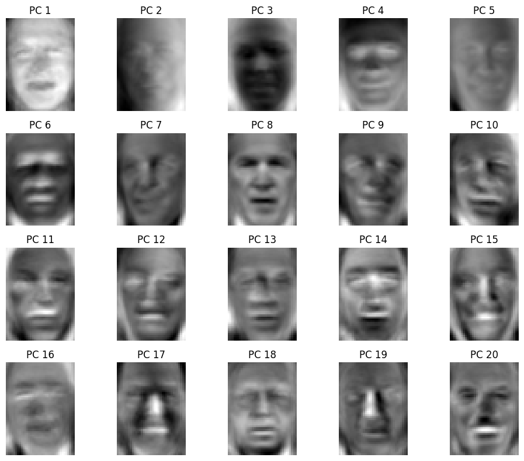

```python
eigenfaces = lfw_pca.components_

h, w = lfw.images.shape[1:3]

fig, axes = plt.subplots(4, 5, figsize=(10, 8))

for i, ax in enumerate(axes.flat):
    ax.imshow(eigenfaces[i].reshape(h, w), cmap='gray')
    ax.set_title(f"PC {i+1}")
    ax.axis('off')

plt.tight_layout()
plt.show()
```

Eigenfaces można rozumieć jako zestaw „podstawowych wzorców twarzy”, któreopisują najważniejsze różnice między obrazami w zbiorze danych. Każda twarz może być przedstawiona jako kombinacja tych wzorców.W przypadku nowego, wcześniej niewidzianego zdjęcia, zamiast analizować wszystkie piksele, obraz jest przekształcany do nowej przestrzeni cech utworzonej przez eigenfaces. W efekcie otrzymujemy krótszy wektor liczb, który mówi, w jakim stopniu dane wzorce (eigenfaces) występują w tym obrazie.

Pierwsze komponenty główne opisują globalne cechy, takie jak oświetlenie i ogólny kształt twarzy. Kolejne komponenty uchwytują bardziej szczegółowe elementy, takie jak oczy, nos i usta, natomiast dalsze odpowiadają za drobne detale i szum.

### Zadanie dodatkowe: Kernel PCA

```python
N = 1000
r1 = 40
r2 = 100
sigma = 1

n_half = N // 2

theta = np.random.uniform(0, np.pi, N)
phi = np.random.uniform(0, 2*np.pi, N)

r = np.concatenate([np.full(n_half, r1), np.full(n_half, r2)])


x = r * np.sin(theta) * np.cos(phi)
y = r * np.sin(theta) * np.sin(phi)
z = r * np.cos(theta)

x += np.random.normal(0, sigma, N)
y += np.random.normal(0, sigma, N)
z += np.random.normal(0, sigma, N)

X = np.vstack([x, y, z]).T
y_labels = np.array([0]*n_half + [1]*n_half)
```

```python
standard_pca = PCA(n_components=2)
X_transformed_pca = standard_pca.fit_transform(X)

print(standard_pca.explained_variance_ratio_)
```

```
[0.5131938  0.26166831]
```

```python
kernel_pca = KernelPCA(n_components=2, kernel='poly', degree=5)
X_transformed_kernel_pca = kernel_pca.fit_transform(X)
print(kernel_pca.eigenvectors_)
```

```
[[ 0.00069613 -0.00024477]
 [ 0.00010039 -0.00049841]
 [ 0.00030854  0.00017178]
 ...
 [ 0.07776337 -0.01736889]
 [ 0.03098372 -0.06929237]
 [-0.02526445  0.03659353]]
```

```python
kernel_pca_rbf = KernelPCA(n_components=2, kernel='rbf', gamma=1/(2*27.8**2))
X_transformed_kernel_pca_rbf = kernel_pca_rbf.fit_transform(X)
```

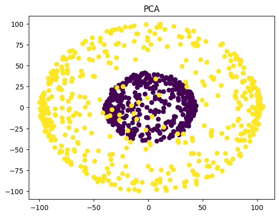

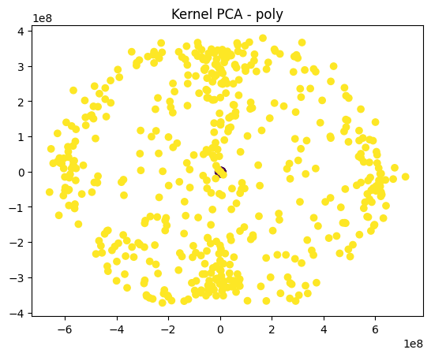

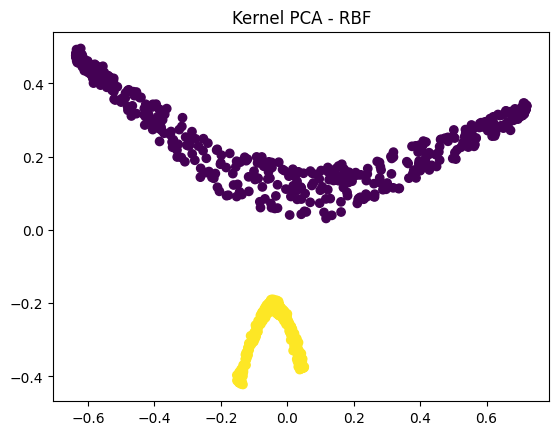

```python
def plot(X_transformed, title):
    plt.scatter(X_transformed[:,0], X_transformed[:,1], c=y_labels)
    plt.title(title)
    plt.show()

plot(X_transformed_pca, "PCA")
plot(X_transformed_kernel_pca, "Kernel PCA - poly")
plot(X_transformed_kernel_pca_rbf , "Kernel PCA - RBF")
```

Jak możemy zauważyć na powyższych wykresach punkty reprezentujace powierzchnie sfer, zostały wpełni odseparowane dopiero, podczas zastosowania modelu Kernel PCA z jądrem typy RBF.

```python
kernel_pca_rbf = KernelPCA(n_components=100, kernel='rbf')

x_train_pca = kernel_pca_rbf.fit_transform(x_train)
x_test_pca = kernel_pca_rbf.transform(x_test)
```

```python
clf_svm = svm.SVC(kernel='linear', C=10, gamma='scale', class_weight='balanced', decision_function_shape='ovo')
clf_svm.fit(x_train_pca, y_train)
```

```
SVC(C=10, class_weight='balanced', decision_function_shape='ovo',
    kernel='linear')
```

```python
clf_rf  = RandomForestClassifier(n_estimators=200, max_depth=20, max_features='sqrt',class_weight='balanced', random_state=42)
clf_rf.fit(x_train_pca, y_train)
```

```
RandomForestClassifier(class_weight='balanced', max_depth=20, n_estimators=200,
                       random_state=42)
```

```python
print('------------------SVM Classifier metrics------------------')
evaluate_model(clf_svm, x_test_pca, y_test)
```

```
------------------SVM Classifier metrics------------------
                   precision    recall  f1-score   support

     Ariel Sharon       0.50      0.48      0.49        21
     Colin Powell       0.84      0.77      0.80        77
  Donald Rumsfeld       0.66      0.72      0.69        32
    George W Bush       0.93      0.64      0.76       162
Gerhard Schroeder       0.55      0.53      0.54        30
      Hugo Chavez       0.61      0.81      0.69        21
   Jacques Chirac       0.39      0.65      0.49        17
    Jean Chretien       0.52      0.88      0.65        17
    John Ashcroft       0.46      0.89      0.61        19
Junichiro Koizumi       0.69      0.85      0.76        13
  Serena Williams       0.50      0.92      0.65        13
       Tony Blair       0.68      0.59      0.63        46

         accuracy                           0.69       468
        macro avg       0.61      0.73      0.65       468
     weighted avg       0.74      0.69      0.70       468
```

```python
print('------------------RF Classifier metrics------------------')
evaluate_model(clf_rf, x_test_pca, y_test)
```

```
------------------RF Classifier metrics------------------
                   precision    recall  f1-score   support

     Ariel Sharon       1.00      0.05      0.09        21
     Colin Powell       1.00      0.35      0.52        77
  Donald Rumsfeld       1.00      0.12      0.22        32
    George W Bush       0.39      1.00      0.56       162
Gerhard Schroeder       0.00      0.00      0.00        30
      Hugo Chavez       1.00      0.05      0.09        21
   Jacques Chirac       0.00      0.00      0.00        17
    Jean Chretien       1.00      0.06      0.11        17
    John Ashcroft       0.00      0.00      0.00        19
Junichiro Koizumi       1.00      0.31      0.47        13
  Serena Williams       1.00      0.77      0.87        13
       Tony Blair       1.00      0.04      0.08        46

         accuracy                           0.45       468
        macro avg       0.70      0.23      0.25       468
     weighted avg       0.65      0.45      0.35       468
```

```python
kernel_pca_rbf_120 = KernelPCA(n_components=120, kernel='rbf')
x_train_120 = kernel_pca_rbf_120.fit_transform(x_train)
x_test_120 =  kernel_pca_rbf_120.transform(x_test)
```

```python
clf_svm = svm.SVC(kernel='linear', C=10, gamma='scale', class_weight='balanced', decision_function_shape='ovo')
clf_svm.fit(x_train_120, y_train)
```

```
SVC(C=10, class_weight='balanced', decision_function_shape='ovo',
    kernel='linear')
```

```python
clf_rf  = RandomForestClassifier(n_estimators=200, max_depth=20, max_features='sqrt',class_weight='balanced', random_state=42)
clf_rf.fit(x_train_120, y_train)
```

```
RandomForestClassifier(class_weight='balanced', max_depth=20, n_estimators=200,
                       random_state=42)
```

```python
print('------------------SVM Classifier metrics------------------')
evaluate_model(clf_svm, x_test_120, y_test)
```

```
------------------SVM Classifier metrics------------------
                   precision    recall  f1-score   support

     Ariel Sharon       0.50      0.48      0.49        21
     Colin Powell       0.85      0.78      0.81        77
  Donald Rumsfeld       0.66      0.72      0.69        32
    George W Bush       0.93      0.67      0.78       162
Gerhard Schroeder       0.52      0.53      0.52        30
      Hugo Chavez       0.62      0.76      0.68        21
   Jacques Chirac       0.37      0.65      0.47        17
    Jean Chretien       0.54      0.88      0.67        17
    John Ashcroft       0.50      0.89      0.64        19
Junichiro Koizumi       0.73      0.85      0.79        13
  Serena Williams       0.52      0.92      0.67        13
       Tony Blair       0.77      0.65      0.71        46

         accuracy                           0.70       468
        macro avg       0.62      0.73      0.66       468
     weighted avg       0.75      0.70      0.71       468
```

```python
print('------------------RF Classifier metrics------------------')
evaluate_model(clf_rf, x_test_120, y_test)
```

```
------------------RF Classifier metrics------------------
                   precision    recall  f1-score   support

     Ariel Sharon       0.00      0.00      0.00        21
     Colin Powell       0.93      0.34      0.50        77
  Donald Rumsfeld       1.00      0.12      0.22        32
    George W Bush       0.39      1.00      0.56       162
Gerhard Schroeder       0.00      0.00      0.00        30
      Hugo Chavez       1.00      0.05      0.09        21
   Jacques Chirac       0.00      0.00      0.00        17
    Jean Chretien       1.00      0.06      0.11        17
    John Ashcroft       0.00      0.00      0.00        19
Junichiro Koizumi       1.00      0.31      0.47        13
  Serena Williams       1.00      0.62      0.76        13
       Tony Blair       1.00      0.09      0.16        46

         accuracy                           0.45       468
        macro avg       0.61      0.21      0.24       468
     weighted avg       0.59      0.45      0.35       468
```

## Zadania dodatkowe: Incremental PCA

Incremental PCA (IPCA) jest wariantem PCA zaprojektowanym do obsługi danych, które nie mieszczą się w pamięci RAM lub są przesyłane w partiach (np. dane z czujników IoT, logi serwerowe). W przeciwieństwie do klasycznego PCA, IPCA aktualizuje model przyrostowo, co pozwala na efektywne przetwarzanie danych w czasie rzeczywistym. W zadaniu zbadamy, jak: — Wielkość partii (batch size) wpływa na dokładność IPCA — Skalowanie danych oddziałuje na wydajność obu metod — Rozmiar zbioru danych determinuje wybór między PCA a IPCA

1. Wygeneruj sztuczny zbiór danych przy użyciu funkcji make blobs z biblioteki scikit-learn: 100 000 próbek, 100 cech, 5 skupisk. from sklearn.datasets import make_blobs X, _ = make_blobs(n_samples=100_000, n_features=100, centers=5)
2. Podziel zbiór danych na treningowy (80%) i testowy (20%)
3. Znormalizuj dane za pomocą StandardScaler
4. Oblicz PCA na całym zbiorze treningowym i zmierz czas oraz zużycie pamięci
5. Zapisz wartość wyjaśnionej wariancji dla pierwszych 10 komponentów
6. Implementacja Incremental PCA — Przetwarzaj dane treningowe partiami (np. batch size=1000) — Użyj metody partial fit() do aktualizacji modelu — Zmierz łączny czas i pamięć zużytą przez IPCA
7. Porównanie wyników: — Dla obu metod wyznacz: wariancję wyjaśnioną (explained variance ratio ), błąd rekonstrukcji (MSE) na zbiorze testowym, czas wykonania i zu- życie pamięci — Narysuj wykres porównujący wariancję wyjaśnioną przez PCA i IPCA. — Skomentuj uzyskane wyniki
8. Analiza skalowalności: — Przeprowadź eksperyment dla różnych rozmiarów zbioru danych (np. 10k, 50k, 100k próbek) — Porównaj czas wykonania PCA i IPCA w zależności od rozmiaru danych
9. Wizualizacja — Dokonaj rzutowania danych na 2 komponenty główne za pomocą obu metod — Narysuj wykresy rozrzutu i porównaj separację skupisk
10. Pytania: — Czy wyniki IPCA są zbliżone do PCA pod względem wariancji wyja- śnionej? Uzasadnij. — Jak zmienia się czas wykonania IPCA w zależności od batch size (np. 100 vs. 5000)? — W jakich scenariuszach praktycznych warto użyć IPCA zamiast PCA? — Dlaczego błąd rekonstrukcji może być większy dla IPCA niż dla PCA?

```python
X, y = make_blobs(n_samples=100_000, n_features=100, centers=5, random_state=42)

x_train, x_test = train_test_split(X, train_size=0.8, test_size=0.2, random_state=42)
scaler = StandardScaler()
x_train_scaled = scaler.fit_transform(x_train)
x_test_scaled = scaler.transform(x_test)
```

```python
from sklearn.decomposition import IncrementalPCA
def train_model(model, X_train, batch_size=None):
    if isinstance(model, IncrementalPCA):
        for start in range(0, X_train.shape[0], batch_size):
            model.partial_fit(X_train[start:start+batch_size])
    else:
        model.fit(X_train)
```

```python
import time

pca = PCA(n_components=10)


def run_pca():
    train_model(pca, x_train_scaled)

start_time = time.time()
mem_usage = memory_usage(run_pca)
end_time = time.time()

total_time = end_time - start_time
mem_used = max(mem_usage) - min(mem_usage)


x_test_pca = pca.transform(x_test_scaled)
x_test_reconstructed_pca = pca.inverse_transform(x_test_pca)

mse_pca = mean_squared_error(x_test_scaled, x_test_reconstructed_pca)

print(f"PCA - MSE: {mse_pca:.6f} Time: {total_time:.4f} s Memory: {mem_used:.2f} MB")
```

```
PCA - MSE: 0.033796 Time: 1.8566 s Memory: 0.00 MB
```

```python
print(f'{pca.explained_variance_=}')
```

```
pca.explained_variance_=array([27.79264065, 25.71166015, 24.61656877, 17.48735475,  0.27970424,
        0.19034983,  0.15762817,  0.13819007,  0.13193155,  0.11974682])
```

```python
ipca = IncrementalPCA(n_components=10)


def run_ipca():
    train_model(ipca, x_train_scaled, batch_size=1000)

start_time = time.time()
mem_usage = memory_usage(run_ipca)
end_time = time.time()

total_time = end_time - start_time

mem_used = max(mem_usage) - min(mem_usage)

x_test_ipca = ipca.transform(x_test_scaled)
x_test_reconstructed_ipca = ipca.inverse_transform(x_test_ipca)

mse_ipca = mean_squared_error(x_test_scaled, x_test_reconstructed_ipca)
print(f"IPCA - MSE: {mse_ipca} Time: {total_time:.4f} s Memory: {mem_used } MB")
```

```
IPCA - MSE: 0.0337998943420774 Time: 4.6048 s Memory: 2.2890625 MB
```

```python
print(f'{ipca.explained_variance_=}')
```

```
ipca.explained_variance_=array([27.79264037, 25.71165982, 24.61656843, 17.48735437,  0.2796719 ,
        0.19027321,  0.15741723,  0.13797117,  0.13149536,  0.11909745])
```

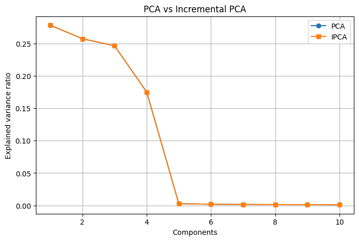

```python
components = np.arange(1, 11)

plt.figure(figsize=(8,5))
plt.plot(components, pca.explained_variance_ratio_, marker='o', label='PCA')
plt.plot(components, ipca.explained_variance_ratio_, marker='s', label='IPCA')
plt.xlabel('Components')
plt.ylabel('Explained variance ratio')
plt.title('PCA vs Incremental PCA')
plt.legend()
plt.grid(True)
plt.show()
```

```python
data_sizes = [10_00, 50_000, 100_000]

models = [PCA(n_components=10), IncrementalPCA(n_components=10)]

for ds in data_sizes:
    print(f'----------Data size:{ds}----------')
    for model in models:
        X, _ = make_blobs(n_samples=ds, n_features=100, centers=5, random_state=42)

        x_train, x_test = train_test_split(X, train_size=0.8, test_size=0.2, random_state=42)
        scaler = StandardScaler()
        x_train_scaled = scaler.fit_transform(x_train)

        s_time =  time.time()
        train_model(model, x_train_scaled, batch_size=1000)
        e_time = time.time()

        if isinstance(model, PCA):
            print(f'PCA training time: {(e_time-s_time):.6f}')
        else:
            print(f'IPCA training time: {(e_time-s_time):.6f}')
```

```
----------Data size:1000----------
PCA training time: 0.009346
IPCA training time: 0.042920
----------Data size:50000----------
PCA training time: 0.022202
IPCA training time: 2.527379
----------Data size:100000----------
PCA training time: 0.037155
IPCA training time: 3.563741
```

```python
def plot_2d_projection_simple(X, labels, method_name="PCA"):
    plt.figure()

    plt.scatter(X[:, 0], X[:, 1], c=labels, cmap='viridis', alpha=0.7)

    plt.title(f"{method_name} projection")
    plt.xlabel(f"{method_name} 1")
    plt.ylabel(f"{method_name} 2")

    plt.grid(True)
    plt.show()
```

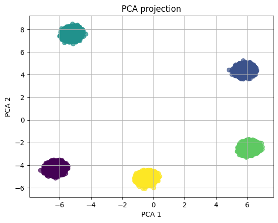

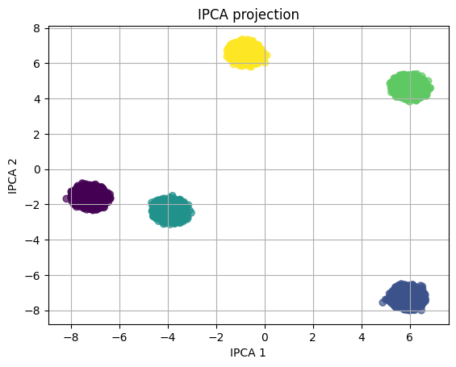

```python
scaler = StandardScaler()
X_scaled = scaler.fit_transform(X)

pca = PCA(n_components=2)
X_pca_2d = pca.fit_transform(X_scaled)

plot_2d_projection_simple(X_pca_2d, y, "PCA")


ipca = IncrementalPCA(n_components=2)
X_ipca_2d = ipca.fit_transform(X_scaled)

plot_2d_projection_simple(X_ipca_2d, y, "IPCA")
```

1. Wyniki Incremental PCA są zazwyczaj bardzo zbliżone do klasycznego PCA pod względem wariancji wyjaśnionej, szczególnie przy odpowiednio dużym rozmiarze batcha. Wynika to z faktu, że IPCA stanowi przybliżenie PCA i dąży do znalezienia tych samych głównych kierunków wariancji. Niewielkie różnice mogą wynikać z przyrostowego charakteru uczenia oraz zależności od kolejności przetwarzania danych.
2. Dla małych batchy (np. 100) czas jest większy, ponieważ model musi wykonać więcej iteracji aktualizacji. Dla większych batchy (np. 5000) liczba iteracji maleje, co przyspiesza obliczenia, jednak kosztem większego zużycia pamięci.
3. Praktyczne zastosowania Incremental PCA:
- zbiór danych jest bardzo duży i nie mieści się w pamięci RAM,
- dane napływają strumieniowo (np. dane z czujników IoT, logi systemowe),
- wymagane jest przetwarzanie danych w czasie rzeczywistym.
4. Błąd rekonstrukcji w przypadku IPCA może być większy niż dla PCA, ponieważ metoda ta operuje na fragmentach danych i aktualizuje model przyrostowo, zamiast analizować cały zbiór jednocześnie. W rezultacie otrzymywane komponenty główne są przybliżeniem rozwiązania optymalnego, co może prowadzić do większej utraty informacji i wyższego błędu rekonstrukcji.